# pSIMS Tutorial

pSIMS Tutorial Hamze Dokoohaki 3/25/2021

## Download Files used in this Tutorial

In this tutorial, I will be using `pSIMSSiteMaker` and `pSIMCampaignManager` packages to first create a ncdf campaign file and then use the newly created campaign file to create a whole pSIMS simulation for a specific site. This tutorial helps to create a gird over a parameter space defined by the user, run the model over the grid and using a series of observations fit a Gaussian process emulator over the likelihood surface.

Before using these packages, I need to mention that `pSIMCampaignManager` depends on two packages of `JBTools` and `ncdf.tools` which both are unfortunately off the CRAN, however you can the following link to find the latests version : [Link to packages](https://github.com/AgronomicForecastingLab/pSIMS_Campaign_Manager/tree/master/inst) and manually install them.

```r
library(pSIMSSiteMaker)
library(pSIMCampaignManager)
```

### Creating an the Campign file

```r
Create_Empty_Campaign(lat=seq(37, 43.5, by=0.25), lon=seq(-83, -96.75, by=-0.25), num_scen=1, filename = "MyCampaign.nc4")
```

To double check and make sure our campaign is in the right format:

```r
Get_Camp_dim("MyCampaign.nc4")
```

```
## $Lat
##  [1] 37.00 37.25 37.50 37.75 38.00 38.25 38.50 38.75 39.00 39.25 39.50 39.75
## [13] 40.00 40.25 40.50 40.75 41.00 41.25 41.50 41.75 42.00 42.25 42.50 42.75
## [25] 43.00 43.25 43.50
##
## $Lon
##  [1] -83.00 -83.25 -83.50 -83.75 -84.00 -84.25 -84.50 -84.75 -85.00 -85.25
## [11] -85.50 -85.75 -86.00 -86.25 -86.50 -86.75 -87.00 -87.25 -87.50 -87.75
## [21] -88.00 -88.25 -88.50 -88.75 -89.00 -89.25 -89.50 -89.75 -90.00 -90.25
## [31] -90.50 -90.75 -91.00 -91.25 -91.50 -91.75 -92.00 -92.25 -92.50 -92.75
## [41] -93.00 -93.25 -93.50 -93.75 -94.00 -94.25 -94.50 -94.75 -95.00 -95.25
## [51] -95.50 -95.75 -96.00 -96.25 -96.50 -96.75
##
## $Scen
## [1] 1
##
## $Extent
## class      : Extent
## xmin       : 36.875
## xmax       : 43.625
## ymin       : -96.875
## ymax       : -82.875
##
## $Count
## [1] 1512
```

We create a vector of desiered parameters that need to be optimized along with their acceptable/reasonable upper and lower boundary. `lenght.out.grid` in this example controls the space between nodes in the parameter space and the higher the number of nodes, we will finer mesh and also larger number of total simulations.

```r
params <- list (
  pars = c("tt_flower_to_maturity",
           "tt_emerg_to_endjuv",
           "tt_flower_to_start_grain"),
  Upper.limit = c(900, 300, 250),
  lower.limit = c(700, 200, 100),
  unit=c('C/day','C/day','C/day')
)

lenght.out.grid <- 4 # the space between points in each dimension in the parameter space

grid <- purrr::pmap(params[c(2,3)], function(Upper.limit, lower.limit) {
  seq(Upper.limit, lower.limit, length.out = lenght.out.grid)
}) %>%
  setNames(params$pars) %>%
  expand.grid()
```

Now let’s see the gird. Each row in this grid is a location of a node in the parameter space and a scenario which we need to run the model over it.

```r
print(grid)
```

```
##    tt_flower_to_maturity tt_emerg_to_endjuv tt_flower_to_start_grain
## 1               900.0000           300.0000                      250
## 2               833.3333           300.0000                      250
## 3               766.6667           300.0000                      250
## 4               700.0000           300.0000                      250
## 5               900.0000           266.6667                      250
## 6               833.3333           266.6667                      250
## 7               766.6667           266.6667                      250
## 8               700.0000           266.6667                      250
## 9               900.0000           233.3333                      250
## 10              833.3333           233.3333                      250
## 11              766.6667           233.3333                      250
## 12              700.0000           233.3333                      250
## 13              900.0000           200.0000                      250
## 14              833.3333           200.0000                      250
```

[output cut: 50 more lines]

So we increase the number of scenarios to the `nrow` of the `grid` variable and add each row as a new scenario.

```r
Add_Scenario("MyCampaign.nc4", nrow(grid)-1)

Get_Camp_dim("MyCampaign.nc4")
```

```
## $Lat
##  [1] 37.00 37.25 37.50 37.75 38.00 38.25 38.50 38.75 39.00 39.25 39.50 39.75
## [13] 40.00 40.25 40.50 40.75 41.00 41.25 41.50 41.75 42.00 42.25 42.50 42.75
## [25] 43.00 43.25 43.50
##
## $Lon
##  [1] -83.00 -83.25 -83.50 -83.75 -84.00 -84.25 -84.50 -84.75 -85.00 -85.25
## [11] -85.50 -85.75 -86.00 -86.25 -86.50 -86.75 -87.00 -87.25 -87.50 -87.75
## [21] -88.00 -88.25 -88.50 -88.75 -89.00 -89.25 -89.50 -89.75 -90.00 -90.25
## [31] -90.50 -90.75 -91.00 -91.25 -91.50 -91.75 -92.00 -92.25 -92.50 -92.75
## [41] -93.00 -93.25 -93.50 -93.75 -94.00 -94.25 -94.50 -94.75 -95.00 -95.25
## [51] -95.50 -95.75 -96.00 -96.25 -96.50 -96.75
##
## $Scen
##  [1]  1  2  3  4  5  6  7  8  9 10 11 12 13 14 15 16 17 18 19 20 21 22 23 24 25
## [26] 26 27 28 29 30 31 32 33 34 35 36 37 38 39 40 41 42 43 44 45 46 47 48 49 50
## [51] 51 52 53 54 55 56 57 58 59 60 61 62 63 64
##
## $Extent
## class      : Extent
## xmin       : 36.875
## xmax       : 43.625
## ymin       : -96.875
## ymax       : -82.875
##
## $Count
## [1] 1512
```

But first for each variable we create a list of matrices which will be used as a scenario.

```r
num_scen <- Get_Camp_dim("MyCampaign.nc4")$Scen

for(param in params$pars) {

  new.values <- purrr::map(seq_along(num_scen), ~Campaign_emptyMatrix("MyCampaign.nc4", grid[[param]][.x] )[[1]])

  AddVar_Campaign("MyCampaign.nc4",
                Variable = list(Name=param,
                                Unit=params$unit[which(params$pars==param)],
                                missingValue=-99,
                                value= new.values
                ),
                attr = list('long_name',"")
                  )
}
```

We can double check the values written in the campign file using the following plots and compare each set of plot with one row of the `grid` variable.

**First and second Scenario**

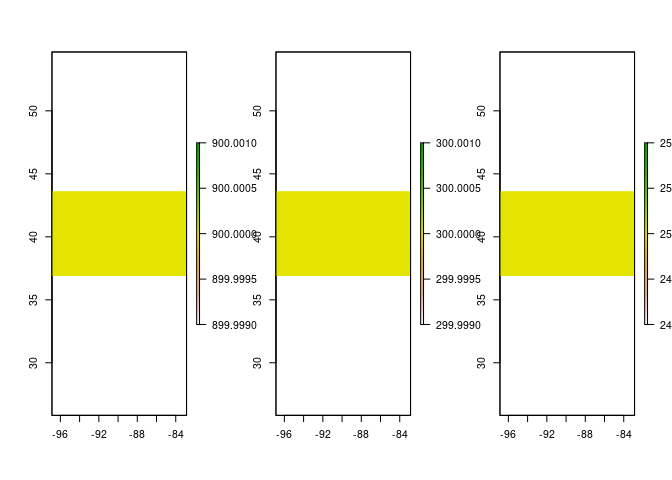

```r
par(mfrow=c(1,3))
plot(GetCamp_VarMatrix("MyCampaign.nc4", params$pars[1])$Raster[[1]])
plot(GetCamp_VarMatrix("MyCampaign.nc4", params$pars[2])$Raster[[1]])
plot(GetCamp_VarMatrix("MyCampaign.nc4", params$pars[3])$Raster[[1]])
```

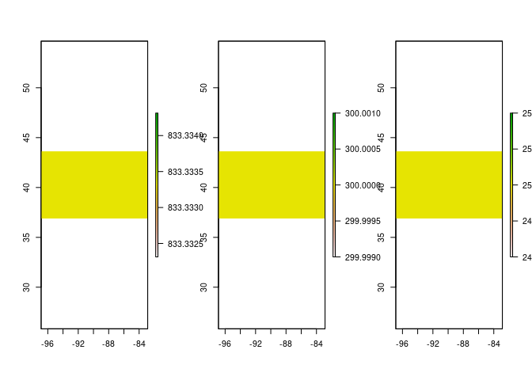

```r
plot(GetCamp_VarMatrix("MyCampaign.nc4", params$pars[1])$Raster[[2]])
plot(GetCamp_VarMatrix("MyCampaign.nc4", params$pars[2])$Raster[[2]])
plot(GetCamp_VarMatrix("MyCampaign.nc4", params$pars[3])$Raster[[2]])
```

Now given the fact that the campign file seems to be in the right format we can start creating the simulation and work on creating an emulator on the model output surface or the likelihood surface given a series of observations.

Finally we will be adding met files in the campaign :

```r
new.values <- purrr::map(Get_Camp_dim("MyCampaign.nc4")$Scen,~Campaign_emptyMatrix("MyCampaign.nc4",
                                                    sample(c(1:9), Get_Camp_dim("MyCampaign.nc4")$Count,TRUE)
)[[1]])



AddVar_Campaign("MyCampaign.nc4",
                Variable = list(Name='file',
                                Unit='Mapping',
                                missingValue=-99,
                                value= new.values
                ),
                attr = list('long_name',"met00000.met,met00001.met,met00002.met,met00003.met,
                            met00004.met,met00005.met,met00006.met,met00007.met,met00008.met,
                            met00009.met")
)

Edit_mapping_var ("MyCampaign.nc4", 'file' , 'long_name', "met00000.met,met00001.met,met00002.met,met00003.met,met00004.met,met00005.met,met00006.met,met00007.met,met00008.met,met00009.met")
```

And Finally we removed the default variable created in the `Create_Empty_Campaign` function :

```r
remove_var_campaign("MyCampaign.nc4", outfile="Campaign2.nc4", varnames=c('myvar'))
```

### Creating pSIMS simulation using the Campaign file

```r
#rename the newly mad campaign
file.copy('Campaign2.nc4', 'Campaign.nc4', overwrite = TRUE)
#Delete previous versions of the run if exists
unlink('/home/hamzed/pSIMS/Emulator', recursive = TRUE)

host <-
  list(name = 'cc-login.campuscluster.illinois.edu',
       user = 'hamzed',
       tunnel = '~/tunnel/tunnel',
       from='/home/hamzed/pSIMS/Emulator',
       to='/projects/aces/hamzed/psims/Data/')

#Modifying the params
tmp_param <- Read_param_template()
tmp_param$ref_year <- 2018L
tmp_param$scens <- as.integer(nrow(grid))

#Modifying the campaign json file
tmp_camp <- Read_Campaign_template()
tmp_camp$reporting_frequency <- "end_day"
tmp_camp$output_variables$name[4] <- "LAI"
tmp_camp$planting$pdate <- "8-may"
tmp_camp$planting$depth <- "38"
tmp_camp$planting$sowing_density <- "8.4"
tmp_camp$planting$row_spacing <- "762"
tmp_camp$fertilizer$initial_amount <- "202"



pSIMS_Site_Make(dirname = "/home/hamzed/pSIMS",
                Project_name = "Emulator",
                Lat=40.04,
                Lon = -88.5,
                Campaign_Path ='Campaign.nc4',
                APSIM_Template_Path="template.apsim",
                Param_template_Obj=tmp_param,
                Campaign_json_Obj = tmp_camp,
                host=host,
                Bash_control=list(pSIMS_Data_Path="/pysims/data", # No need to edit this
                                  pSIMS_server_Path="/projects/aces/hamzed/psims/Data",
                pSIMS_Sing_Image="/projects/aces/mkivi2/psims/Bash/apsim_psims_image/custom_psims_full.img")
                )
```

```r
remote.copy.from(host=host,
                 src='/projects/aces/hamzed/psims/Data/sims/Emulator',
                 dst='/home/hamzed/pSIMS/Emulator/Results',
                 delete = TRUE)
```

### Using the simulation outputs to fit a GP as an emulator

Now that we have model results brought back to our local machine, we can start working with the outputs and create the GP model.

```r
Model.results <- list.files("/home/hamzed/pSIMS/Emulator/Results",".out", recursive = TRUE, full.names = TRUE) %>%
  purrr::map_dfr(function(.x){
    print(.x)

    hdr <-     as.character(sapply(as.vector(read.table(file = .x,
        header = FALSE, sep = "", nrows = 1, skip = 2)[1, ]),
        FUN = function(x) x[[1]]))

     read.table(file = .x, header = FALSE,  sep = "", skip = 4) %>%
      `colnames<-`(c(hdr)) %>%
       dplyr::mutate(Date=as.Date(Date, format = "%d/%m/%Y"),
              name=basename(.x)) %>%
       dplyr::select(Date, LAI, name)

  })
```

```
## [1] "/home/hamzed/pSIMS/Emulator/Results/Emulator/5996/10980/Generic.out"
## [1] "/home/hamzed/pSIMS/Emulator/Results/Emulator/5996/10980/Generic1.out"
## [1] "/home/hamzed/pSIMS/Emulator/Results/Emulator/5996/10980/Generic10.out"
## [1] "/home/hamzed/pSIMS/Emulator/Results/Emulator/5996/10980/Generic11.out"
## [1] "/home/hamzed/pSIMS/Emulator/Results/Emulator/5996/10980/Generic12.out"
## [1] "/home/hamzed/pSIMS/Emulator/Results/Emulator/5996/10980/Generic13.out"
## [1] "/home/hamzed/pSIMS/Emulator/Results/Emulator/5996/10980/Generic14.out"
## [1] "/home/hamzed/pSIMS/Emulator/Results/Emulator/5996/10980/Generic15.out"
## [1] "/home/hamzed/pSIMS/Emulator/Results/Emulator/5996/10980/Generic16.out"
## [1] "/home/hamzed/pSIMS/Emulator/Results/Emulator/5996/10980/Generic17.out"
## [1] "/home/hamzed/pSIMS/Emulator/Results/Emulator/5996/10980/Generic18.out"
## [1] "/home/hamzed/pSIMS/Emulator/Results/Emulator/5996/10980/Generic19.out"
## [1] "/home/hamzed/pSIMS/Emulator/Results/Emulator/5996/10980/Generic2.out"
## [1] "/home/hamzed/pSIMS/Emulator/Results/Emulator/5996/10980/Generic20.out"
## [1] "/home/hamzed/pSIMS/Emulator/Results/Emulator/5996/10980/Generic21.out"
```

[output cut: 49 more lines]

Now let’s look at the model simulations for the LAI :

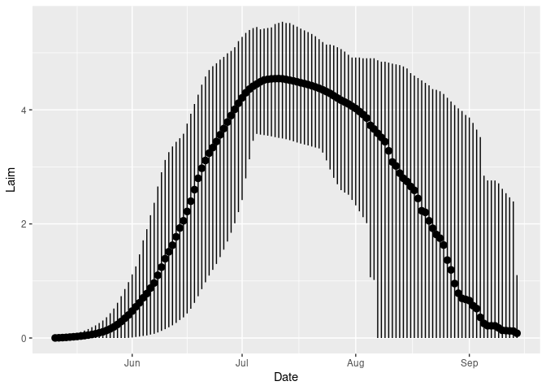

```r
library(ggplot2)

Model.results.summ <- Model.results %>%
  dplyr::group_by(Date) %>%
  summarise(
    Laim=mean(LAI),
    LaiUL=quantile(LAI, probs=0.975),
    LaiLL=quantile(LAI, probs=0.025)
  )

Model.results.summ%>%
  filter(Laim>0)%>%
  ggplot(aes(Date, Laim))+
  geom_pointrange(aes(ymin=LaiLL, ymax=LaiUL))
```

In the above plot and for optimizing phenological paramters, the ideal outcome is to have estimates with large uncertainty throughout the growing season.

In the meantime, we will need a series of obs data for the LAI, which in this example the obs data already exists and it looks like below:

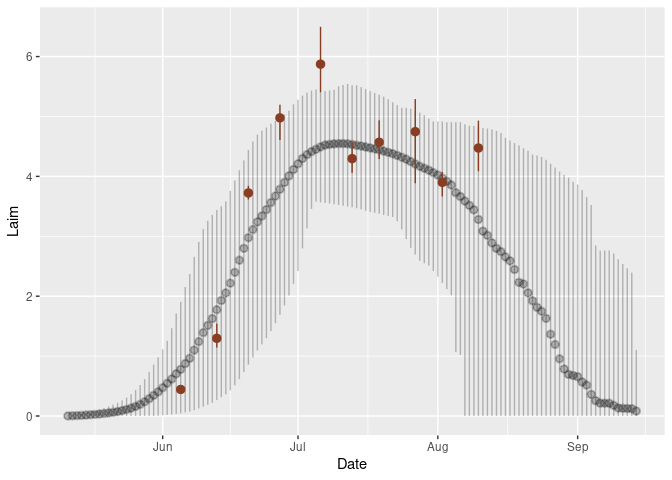

```r
LAI_Obs <- readr::read_csv("LAI_OBS.csv") %>%
  mutate(Date=as.Date(Date)) %>%
  group_by(Date) %>%
  summarise(
    UL=quantile(LAI, probs=0.975),
    LL=quantile(LAI, probs=0.025),
    Mean=mean(LAI, na.rm=TRUE),
    Median=median(LAI, na.rm=TRUE)
  ) %>%
  mutate(Year=lubridate::year(Date),
         Dif=UL-LL) %>%
  filter(Dif !=0)

Model.results.summ%>%
  filter(Laim>0)%>%
  ggplot(aes(Date, Laim))+
  geom_pointrange(aes(ymin=LaiLL, ymax=LaiUL), alpha=0.25)+
  geom_pointrange(aes(x=Date, y=Mean, ymin=LL, ymax=UL), data=LAI_Obs, color="#873e23")
```

Next we will select simulated LAIs where we have observation for and fit the gp model:

```r
library(mlegp)

Model.results.gp.ready <- Model.results %>%
  filter(Date %in% LAI_Obs$Date)

grid$Scenario <- c(0:(nrow(grid)-1))%>%paste0("Generic",.,".out") %>%
  {ifelse(.=="Generic0.out","Generic.out",.)}


#one model for each date
dats <- unique(Model.results.gp.ready$Date)

GPs <-  dats%>%
  map(possibly(function(one.date){

     tmp.grid <- grid
     tmp.res <-  Model.results.gp.ready %>%
          filter(Date == one.date)

    full.grid <- tmp.grid %>%
      left_join(tmp.res,
        by=c('Scenario'='name')
      ) %>%
      dplyr::select(-Scenario, -Date)

    suppressMessages({
          mlegp::mlegp(
      X = full.grid[, 1: length(params$pars)],
      Z = full.grid[, ncol(full.grid), drop = FALSE],
      nugget = 0,
      nugget.known = 1,
      verbose = 0
    )

    })


  } ,otherwise = NULL)) %>%
  setNames(dats) %>%
  purrr::discard(is.null)
```

Here we write a simple function to use the emulators at each date to create a time series of simulated response variable for fitting :

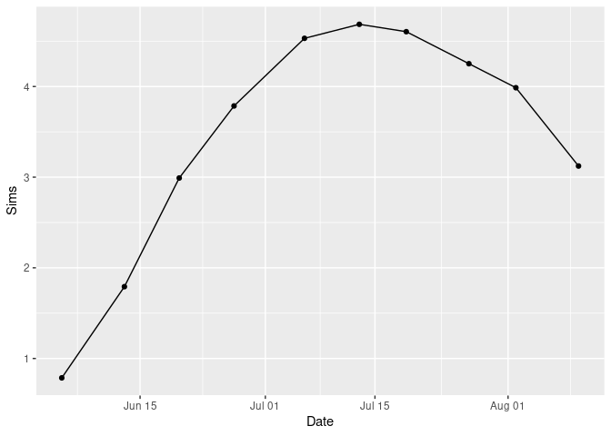

```r
Simulator <- function(newParam=data.frame(), GPs){

  values <- GPs %>%
    purrr::map_dbl( ~ predict.gp(.x, newData = newParam))

  data.frame(
    Date = names(GPs),
    Sims=values
  )

}

Simulator(newParam = data.frame(tt_flower_to_maturity=610,
                                tt_emerg_to_endjuv=262,
                                tt_flower_to_start_grain= 68),
          GPs) %>%
  mutate(Date=as.Date(Date))%>%
  ggplot(aes(Date, Sims))+
  geom_point()+
  geom_line()
```

### Using numerical optimization (optim) to find the most optimum parameters

```r
objfun <- function(prms, odata){

  sims <- Simulator(newParam = data.frame(tt_flower_to_maturity = prms[1],
                                          tt_emerg_to_endjuv = prms[2],
                                          tt_flower_to_start_grain = prms[3]),
                    GPs) %>%
    mutate(Date=as.Date(Date))

  com.df <- odata %>%
    left_join(sims, by='Date') %>%
    filter(!is.na(Sims))
  ### Arbitary index
  rss<-sum(((com.df$Mean)-com.df$Sims)^2)

  rss
}

### just to check and see how the function works
#objfun(c(850, 150, 50), odata = LAI_Obs)


### real optim function
op <- optim(c(850, 150, 50),
            objfun,
            method="L-BFGS-B",
            odata = LAI_Obs,
            lower = params$lower.limit,
            upper =  params$Upper.limit,
            control = list(trace = 1, ndeps=c(2, 2, 2))
                           )

saveRDS(op, file="Optim_out.RDS")
```

```r
op <- readRDS("Optim_out.RDS")
print(op)
```

```
## $par
## [1] 831.9353 250.6703 138.0241
##
## $value
## [1] 6.122708
##
## $counts
## function gradient
##       60       60
##
## $convergence
## [1] 0
##
## $message
## [1] "CONVERGENCE: REL_REDUCTION_OF_F <= FACTR*EPSMCH"
```

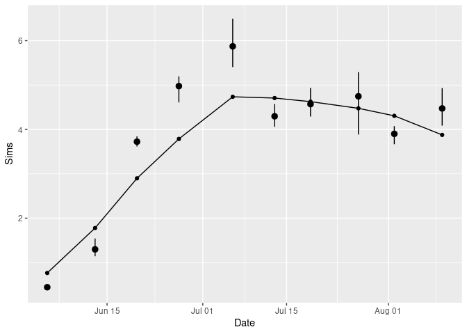

```r
Simulator(newParam = data.frame(tt_flower_to_maturity=op$par[1],
                                tt_emerg_to_endjuv=op$par[2],
                                tt_flower_to_start_grain= op$par[3]),
          GPs) %>%
  mutate(Date=as.Date(Date))%>%
  ggplot(aes(Date, Sims))+
  geom_point()+
  geom_line()+
  geom_pointrange(aes(ymin=LL, ymax=UL, x=Date, y=Mean), data=LAI_Obs)
```

### Optimisation with the Shuffle Complex Evolution method

```r
library(rtop)

objfun <- function(prms, odata){

  sims <- Simulator(newParam = data.frame(tt_flower_to_maturity = prms[1],
                                          tt_emerg_to_endjuv = prms[2],
                                          tt_flower_to_start_grain = prms[3]),
                    GPs) %>%
    mutate(Date=as.Date(Date))

  com.df <- odata %>%
    left_join(sims, by='Date') %>%
    filter(!is.na(Sims))
  ### Arbitary index
  rss<-sum(((com.df$Mean)-com.df$Sims)^2)

  rss
}

### real optim function
sceuares <-
  sceua(
    objfun,
    pars = c(751, 234, 181),
    lower = params$lower.limit,
    upper = params$Upper.limit,
    odata = LAI_Obs
  )

saveRDS(sceuares, file="sceua_out.RDS")
```

```r
op_sce <- readRDS("sceua_out.RDS")
print(op_sce)
```

```
## $par
## [1] 751.3503 234.3428 181.5699
##
## $value
## [1] 4.271882
##
## $convergence
## $convergence$funConvergence
## [1] 0.000172
##
## $convergence$parConvergence
## [1] 0.5745246
##
##
## $counts
## [1] 605
##
## $iterations
## [1] 18
##
## $timeout
## [1] FALSE
```

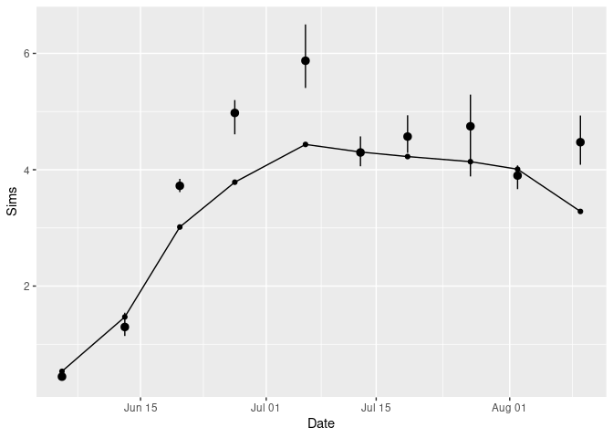

```r
Simulator(newParam = data.frame(tt_flower_to_maturity=op_sce$par[1],
                                tt_emerg_to_endjuv=op_sce$par[2],
                                tt_flower_to_start_grain= op_sce$par[3]),
          GPs) %>%
  mutate(Date=as.Date(Date))%>%
  ggplot(aes(Date, Sims))+
  geom_point()+
  geom_line()+
  geom_pointrange(aes(ymin=LL, ymax=UL, x=Date, y=Mean), data=LAI_Obs)
```

### Using Bayesian optimization to find the most optimum parameters

```r
library(nimble)

predic_R_func <- function(sp1, sp2, sp3){

    sims <- Simulator(newParam = data.frame(tt_flower_to_maturity = sp1,
                                          tt_emerg_to_endjuv = sp2,
                                          tt_flower_to_start_grain = sp3),
                    GPs) %>%
    mutate(Date=as.Date(Date))

  com.df <- LAI_Obs %>%
    left_join(sims, by='Date') %>%
    filter(!is.na(Sims))
  ### Arbitary index
  LAI.sim<-com.df$Sims

 return(LAI.sim)
}
# --------------------------------------------This introduces my function to nimble
predic_NIMBLE_func <- nimbleRcall(
  function(sp = double(),
           sp2 = double(),
           sp3 = double()){}, Rfun = 'predic_R_func',
returnType = double(1) # This means the output is a vector - double(2) means it's a matrix
)

#--------------------------------------This does the real fitting
code <- nimbleCode({

  sp1 ~ T(dnorm(810, 50), 400, 950) # truncated between 400-950, normal with mean=500 and sd=50
  sp2 ~ T(dnorm(260, 20), 10, 400) # truncated between 400-950, normal with mean=500 and sd=50
  sp3 ~ T(dnorm(30, 10), 10, 250) # truncated between 400-950, normal with mean=500 and sd=50

  sigma ~ dunif(0, 5)

  predicted.y[1:N] <- predic_NIMBLE_func(sp1, sp2, sp3) # We are estimating the mean

  for(i in 1:N) { # for each obs - This is the liklihood
    y[i] ~ dnorm(predicted.y[i], sd = sigma)
  }
})
# this checks the model and registers it as an R obj
model <- nimbleModel(code,
                     data = list(y = LAI_Obs$Mean),
                     inits = list(sp1=800,
                                  sp2=250,
                                  sp3=50,
                                  sigma=0.5),
                     constants = list(N=length(LAI_Obs$Mean))
                     )

model$initializeInfo()
```

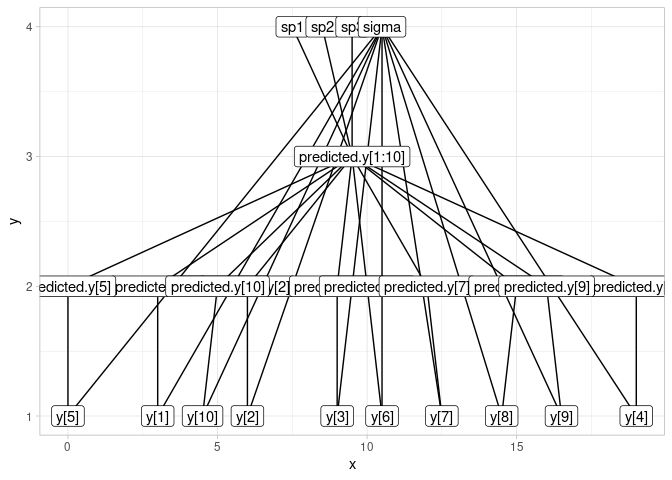

```r
library(ggraph)
ggraph(model$graph, layout = 'auto') +
  geom_edge_link() +
  geom_node_point() +
  geom_node_label(aes(label=name))+
  theme_light()+
  theme(legend.position = 'bottom')
```

```r
mcmcConf <- configureMCMC(model)
```

```
## ===== Monitors =====
## thin = 1: sp1, sp2, sp3, sigma
## ===== Samplers =====
## RW sampler (4)
##   - sp1
##   - sp2
##   - sp3
##   - sigma
```

```r
mcmcConf$printSamplers()
```

```
## [1] RW sampler: sp1
## [2] RW sampler: sp2
## [3] RW sampler: sp3
## [4] RW sampler: sigma
```

```r
DEmcmc1 <- buildMCMC(mcmcConf)
#---- Alternative way to the two line code for running MCMC
DEsamples <- nimbleMCMC(code=model,
                        niter = 2500,
                        nburnin = 500,
                        nchains=1,
                        samplesAsCodaMCMC = TRUE)
saveRDS(DEsamples, file="BOptim_out.RDS")
```

```r
DEsamples <- readRDS("BOptim_out.RDS")
#summary state
nimble::samplesSummary(DEsamples)
```

```
##              Mean      Median   St.Dev.   95%CI_low  95%CI_upp
## sigma   0.9585892   0.9210216 0.2704210   0.5920407   1.636908
## sp1   810.0007939 809.9998069 0.1374972 809.7286695 810.267461
## sp2   259.9875151 259.9967709 0.2310728 259.5116160 260.413286
## sp3    30.0003328  30.0013643 0.3224282  29.3276734  30.595806
```

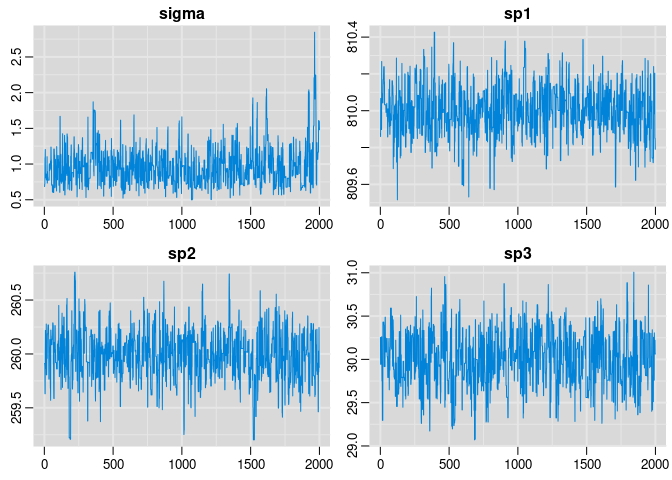

```r
mcmcplots::traplot(DEsamples)
```

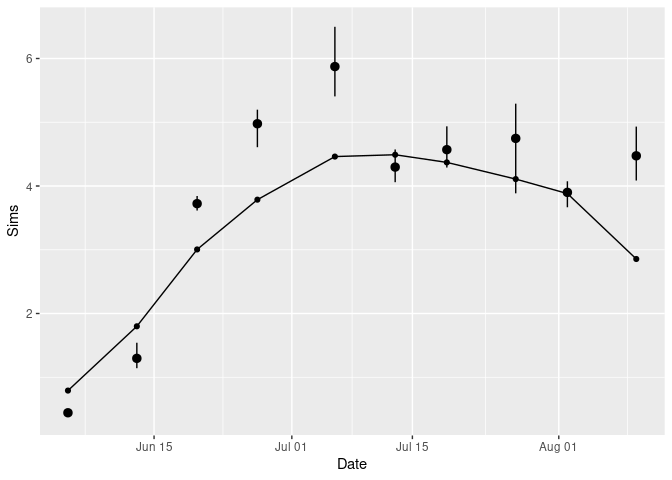

```r
Simulator(newParam = data.frame(tt_flower_to_maturity=mean(DEsamples[,2]),
                                tt_emerg_to_endjuv=mean(DEsamples[,3]),
                                tt_flower_to_start_grain= mean(DEsamples[,4])
                                ),
          GPs) %>%
  mutate(Date=as.Date(Date))%>%
  ggplot(aes(Date, Sims))+
  geom_point()+
  geom_line()+
  geom_pointrange(aes(ymin=LL, ymax=UL, x=Date, y=Mean), data=LAI_Obs)
```